# Notebook

### Web Information Retrieval and Data Mining - Assignment 3

```
Student: Albrechts, Jeroen (0949918)
```

#### Answer 1.1, Baseline (4p)

- Dense network, at least 3 layers, shaped like a pyramid
  - Last layer: 10 nodes, sigmoid.
  - Loss: categorical cross-entropy. Metric: accuracy
- No preprocessing, regularization. Get at least 70% accuracy.
- Explain design decisions. Discuss performance.
  - Does it overfit (large/growing gap between loss and val_loss)?

[output not shown]

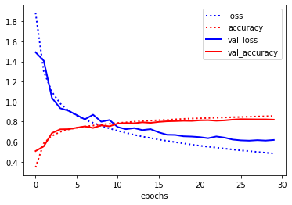

```
Model: "sequential"
_________________________________________________________________
Layer (type)                 Output Shape              Param #
=================================================================
reshape (Reshape)            (None, 3072)              0
_________________________________________________________________
dense (Dense)                (None, 400)               1229200
_________________________________________________________________
dense_1 (Dense)              (None, 200)               80200
_________________________________________________________________
dense_2 (Dense)              (None, 100)               20100
_________________________________________________________________
dense_3 (Dense)              (None, 10)                1010
=================================================================
Total params: 1,330,510
Trainable params: 1,330,510
Non-trainable params: 0
_________________________________________________________________
None
def build_model_1_1():
  model = models.Sequential()
  model.add(layers.Reshape((3072,), input_shape=(32,32,3)))
  model.add(layers.Dense(400, activation='relu'))
  model.add(layers.Dense(200, activation='relu'))
  model.add(layers.Dense(100, activation='relu'))
  model.add(layers.Dense(10, activation='softmax'))

  model.compile(optimizer=optimizers.Adagrad(lr=0.01),
                loss='categorical_crossentropy',
                metrics=['accuracy'])
  return model
```

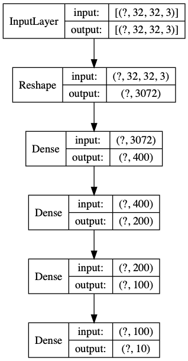

#### Answer 1.2, Preprocess (2p)

- Convert images to greyscale, other preprocessing optional.
  - Input shape should be (32,32,1)
- Explain design decisions. Is it better? Why (not)?
  - Color information is likely not so useful for classification. Greyscale makes the network smaller, less parameters to learn, less likely to overfit.

[output not shown]

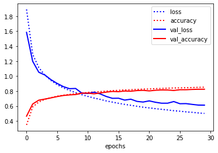

```
Model: "sequential_21"
_________________________________________________________________
Layer (type)                 Output Shape              Param #
=================================================================
reshape_21 (Reshape)         (None, 1024)              0
_________________________________________________________________
dense_85 (Dense)             (None, 400)               410000
_________________________________________________________________
dense_86 (Dense)             (None, 200)               80200
_________________________________________________________________
dense_87 (Dense)             (None, 100)               20100
_________________________________________________________________
dense_88 (Dense)             (None, 10)                1010
=================================================================
Total params: 511,310
Trainable params: 511,310
Non-trainable params: 0
_________________________________________________________________
None
def build_model_1_2():
  model = models.Sequential()
  model.add(layers.Reshape((1024,), input_shape=(32,32,1)))
  model.add(layers.Dense(400, activation='relu'))
  model.add(layers.Dense(200, activation='relu'))
  model.add(layers.Dense(100, activation='relu'))
  model.add(layers.Dense(10, activation='softmax'))

  model.compile(optimizer=optimizers.Adagrad(lr=0.01),
                loss='categorical_crossentropy',
                metrics=['accuracy'])
  return model
```

#### Answer 1.3, Tune (4p)

- Regularize the model. What works best?
  - Should consider batch normalization, dropout, l1/l2 regularization (or Nesterov)
- Tune other hyperparameters (e.g. learning rate, batch size,...) as you see fit.
  - At least consider tuning learning rate, ideally also momentum, decay, other optimizers
- Explain your findings and final design decisions. Discuss the results.
  - Should be better, at least it shouldn't overfit

[output not shown]

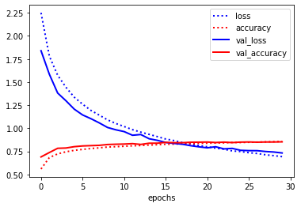

```
def build_model_1_3():
  model = models.Sequential()
  model.add(layers.Reshape((1024,), input_shape=(32,32,1)))
  model.add(layers.BatchNormalization())
  model.add(layers.Dense(400, kernel_regularizer=regularizers.l2(0.001), activation='relu'))
  model.add(layers.BatchNormalization())
  model.add(layers.Dense(200, kernel_regularizer=regularizers.l2(0.001), activation='relu'))
  model.add(layers.BatchNormalization())
  model.add(layers.Dense(100, kernel_regularizer=regularizers.l2(0.001), activation='relu'))
  model.add(layers.BatchNormalization())
  model.add(layers.Dense(10, activation='softmax'))

  model.compile(optimizer=optimizers.Adagrad(lr=0.01),
                loss='categorical_crossentropy',
                metrics=['accuracy'])

  return model
```

#### Answer 2.1, ConvNet (7p)

- Build a sequential ConvNet, get at least 90% accuracy.
  - Conv2D layers, input shape (32,32,1)
  - Consider using blocks of Conv2D layers with maxpooling in between
  - Use zero-padding in Conv2D layers because the images are small
  - At least one dense hidden layer and dense output layer (sigmoid)
  - Consider adding batch normalization, dropout
  - Consider small dropout rates in beginning, larger dropout rates later in network
  - Consider other optimizers and tuning learning rate, momentum,...
- Explain what you did and why (800 chars). Is it working well?
  - Should be quite elaborate and sensible

[output not shown]

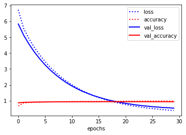

```
Model: "sequential_4"
_________________________________________________________________
Layer (type)                 Output Shape              Param #
=================================================================
batch_normalization_4 (Batch (None, 32, 32, 1)         4
_________________________________________________________________
conv2d (Conv2D)              (None, 30, 30, 64)        640
_________________________________________________________________
conv2d_1 (Conv2D)            (None, 28, 28, 64)        36928
_________________________________________________________________
max_pooling2d (MaxPooling2D) (None, 14, 14, 64)        0
_________________________________________________________________
batch_normalization_5 (Batch (None, 14, 14, 64)        256
_________________________________________________________________
conv2d_2 (Conv2D)            (None, 12, 12, 128)       73856
_________________________________________________________________
max_pooling2d_1 (MaxPooling2 (None, 6, 6, 128)         0
_________________________________________________________________
batch_normalization_6 (Batch (None, 6, 6, 128)         512
_________________________________________________________________
conv2d_3 (Conv2D)            (None, 4, 4, 256)         295168
_________________________________________________________________
max_pooling2d_2 (MaxPooling2 (None, 2, 2, 256)         0
_________________________________________________________________
batch_normalization_7 (Batch (None, 2, 2, 256)         1024
_________________________________________________________________
flatten (Flatten)            (None, 1024)              0
_________________________________________________________________
dropout (Dropout)            (None, 1024)              0
_________________________________________________________________
dense_16 (Dense)             (None, 4096)              4198400
_________________________________________________________________
dropout_1 (Dropout)          (None, 4096)              0
_________________________________________________________________
dense_17 (Dense)             (None, 2048)              8390656
_________________________________________________________________
dropout_2 (Dropout)          (None, 2048)              0
_________________________________________________________________
dense_18 (Dense)             (None, 1024)              2098176
_________________________________________________________________
```

[output cut: 30 more lines]

```
                           kernel_regularizer=kernelreg))
  convnet.add(layers.Dropout(0.5))
  convnet.add(layers.Dense(2 * 1024, activation='relu', kernel_initializer=kernelinit,
                           kernel_regularizer=kernelreg))
  convnet.add(layers.Dropout(0.5))
  convnet.add(layers.Dense(1 * 1024, activation='relu', kernel_initializer=kernelinit,
                           kernel_regularizer=kernelreg))
  convnet.add(layers.Dense(10, activation='softmax', kernel_initializer=kernelinit,
                           kernel_regularizer=kernelreg))

  convnet.compile(optimizer=optimizers.Adagrad(lr=0.01),
                loss='categorical_crossentropy',
                metrics=['accuracy'])

  return convnet
```

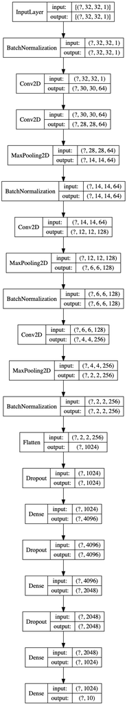

#### Answer 2.2, Data Augmentation (3p)

- Augment the preprocessed training data.
  - Use small variations (small shifts up-down, left-right) of flips becasue the images are small
  - Large shifts and rotations distort the image too much
- Explain what you did and why. Discuss the performance of the model.

[output not shown]

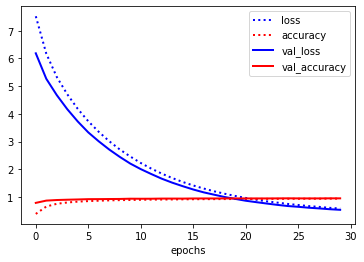

```
train_datagen = ImageDataGenerator(
    #rotation_range=15,
    width_shift_range=0.2,
    height_shift_range=0.2)
```

#### Answer 3.1, Misclassifications (2p)

[output not shown]

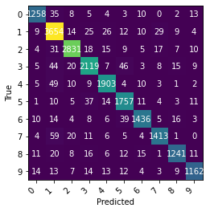

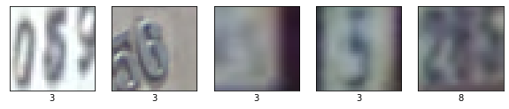

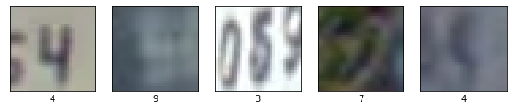

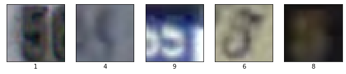

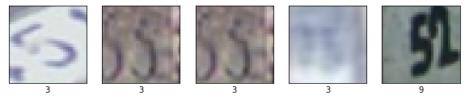

```
Misclassified images with true label 5
```

#### Answer 3.2, Activations (4p)

- Retrieve and visualize the activations for one example
- For every filter for different convolutional layers (at different depths in the network).
- Give an explanation. Is your model indeed learning something useful?
  - Should detect edges etc in first layers, higher-order object (e.g. interesting regions) in deeper layers.

[output not shown]

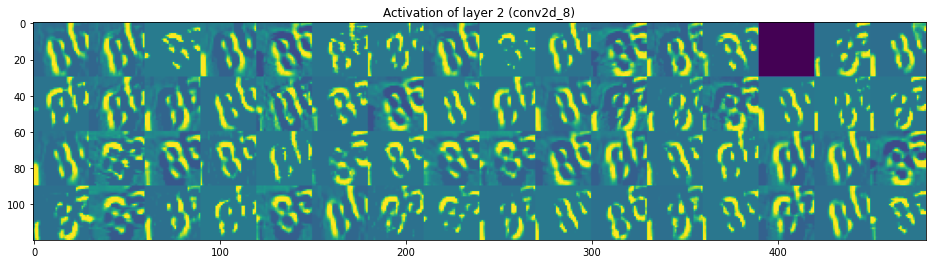

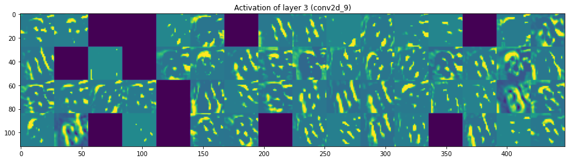

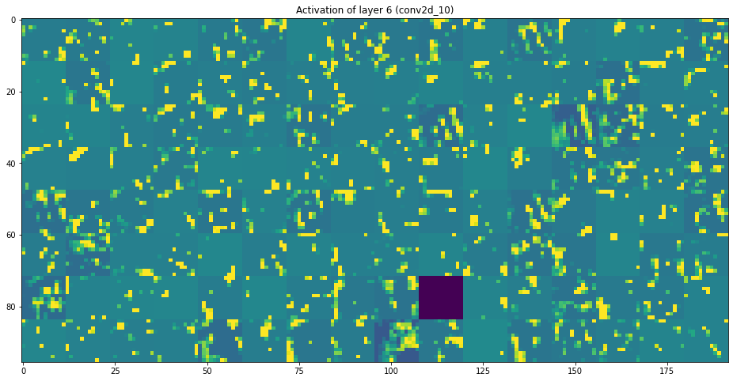

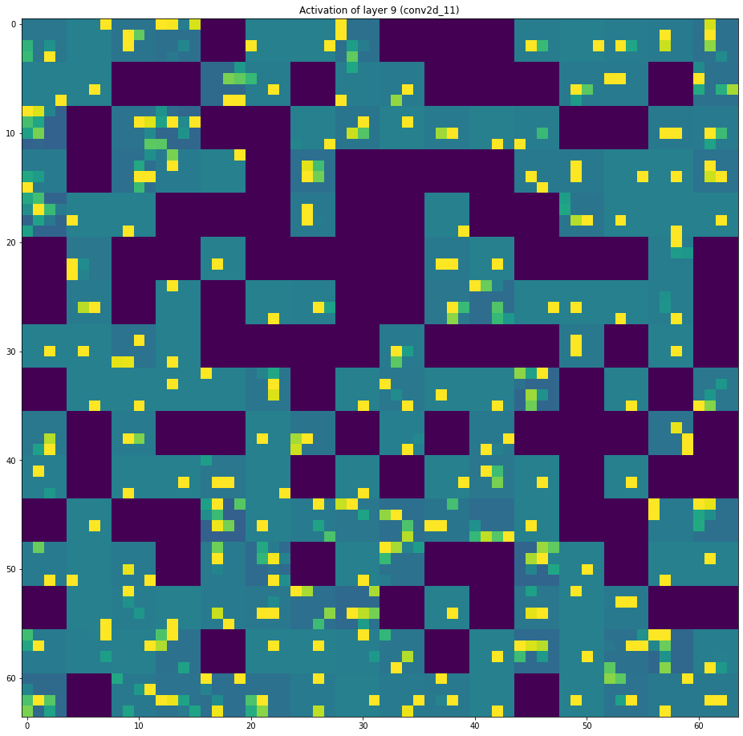

#### Answer 3.3, Class activation map (4p)

- Show a class activation map for your last convolutional layer
- Superimpose the activation map over the image, or plot side by side
  - Should make sense, detect interesting regions to classify the number

```
Model predicts label as 8 while true label is 8
```

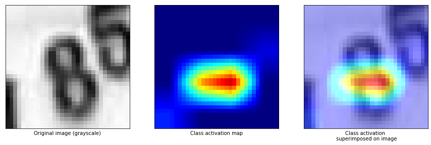

```
def plot_activation_map():
  name = "model_2_2"
  index = 0
  model = load_model_from_file(base_dir, name)
  if not model:
      shout("Model not found")
      return

  testdata = rgb2gray(X_test)
  x = np.expand_dims(testdata[index], axis=0)
  preds = model.predict(x)
  pred_label = (np.argmax(preds) + 1) % 10
  actual_label = (np.argmax(y_test[index]) + 1) % 10
  print("Model predicts label as", str(pred_label), "while true label is", str(actual_label))

  # code is obtained from provided notebook
  model_output = model.output[:, np.argmax(preds)]

  # The is the output feature map of the `block5_conv3` layer,
  # the last convolutional layer in VGG16
  last_conv_layer = model.get_layer('conv2d_11')

  # This is the gradient of the "african elephant" class with regard to
  # the output feature map of `block5_conv3`
  grads = K.gradients(model_output, last_conv_layer.output)[0]

  # This is a vector of shape (512,), where each entry
  # is the mean intensity of the gradient over a specific feature map channel
  pooled_grads = K.mean(grads, axis=(0, 1, 2))

  # This function allows us to access the values of the quantities we just defined:
  # `pooled_grads` and the output feature map of `block5_conv3`,
  # given a sample image
  iterate = K.function([model.input], [pooled_grads, last_conv_layer.output[0]])

  # These are the values of these two quantities, as Numpy arrays,
  # given our sample image of two elephants
  pooled_grads_value, conv_layer_output_value = iterate([x])

  # We multiply each channel in the feature map array
```

[output cut: 13 more lines]

```
  img = testdata[index]

  # We resize the heatmap to have the same size as the original image
  heatmap = cv2.resize(heatmap, (img.shape[1], img.shape[0]))

  # We convert the heatmap to RGB
  heatmap = np.uint8(255 * heatmap)

  # We apply the heatmap to the original image
  heatmap = cv2.applyColorMap(heatmap, cv2.COLORMAP_JET)
  heatmap = cv2.cvtColor(heatmap, cv2.COLOR_BGR2RGB)

  # 0.4 here is a heatmap intensity factor
  superimposed_img = heatmap * 0.0025 + img
  return img, heatmap, superimposed_img
```

#### Answer 4.1, Fast feature extraction (5p)

- Import the VGG16 model, pretrained on ImageNet
- Freeze convolutional base, adds a dense layer
- Consider unfreezing the last few convolutional layers and evaluate whether that works better
  - Check if they do. It is very likely to help.
- Discuss the observed performance
  - Should get around 80% accuracy

[output not shown]

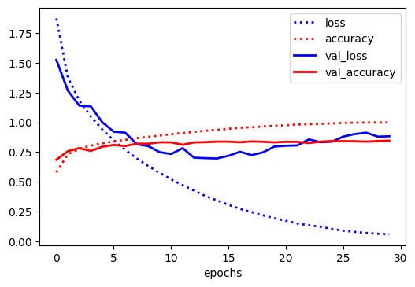

```
Model: "sequential_25"
_________________________________________________________________
Layer (type)                 Output Shape              Param #
=================================================================
vgg16 (Model)                (None, 1, 1, 512)         14714688
_________________________________________________________________
flatten_22 (Flatten)         (None, 512)               0
_________________________________________________________________
dense_72 (Dense)             (None, 1024)              525312
_________________________________________________________________
dense_73 (Dense)             (None, 10)                10250
=================================================================
Total params: 15,250,250
Trainable params: 7,614,986
Non-trainable params: 7,635,264
_________________________________________________________________
None
def build_model_4_1():
  block5_trainable=True

  kernelinit = initializers.VarianceScaling(distribution='uniform', mode='fan_avg')
  kernelreg = regularizers.l2(0.001)

  conv_base = VGG16(weights='imagenet',
                  include_top=False,
                  input_shape=(32, 32, 3))

  model = models.Sequential()
  model.add(conv_base)
  model.add(layers.Flatten())
  model.add(layers.Dense(1024, activation='relu', kernel_initializer=kernelinit,
                           kernel_regularizer=kernelreg))
  model.add(layers.Dense(10, activation='softmax', kernel_initializer=kernelinit,
                           kernel_regularizer=kernelreg))

  conv_base.trainable = True

  set_trainable = False
  for layer in conv_base.layers:
      if layer.name == 'block5_conv1' and block5_trainable:
          set_trainable = True
      if set_trainable:
          layer.trainable = True
      else:
          layer.trainable = False

  model.compile(optimizer=optimizers.Adagrad(lr=0.01),
                loss='categorical_crossentropy',
                metrics=['accuracy'])

  return model
```

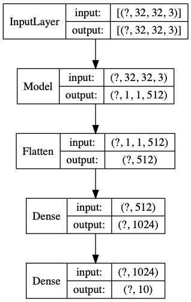

#### Answer 4.2, Embeddings (5p)

- Generate embeddings with the trained convolutional part of model_4_1 (without the dense layer)
- Embed the training and test data and store them to disk
- Build and evaluate a pipeline on the embedded data
  - Check if pipeline makes sense (e.g. use models that can handle many dimensions)
- Describe what you did and what you observed (max 800 chars).
  - Consider different models, preprocessing, tuning, etc.
  - Check performance (see original Submission.html) when in doubt. We did not run all the evaluations because it takes too long, and the output is ill-defined.

[output not shown]

```
Running time: 86.14 seconds
Last modified: May 26, 2020
scikit-learn version: 0.23.1
```